# Covid-19 in numbers

## EU

```r
# Import data
covid19_testing <- read.csv("https://opendata.ecdc.europa.eu/covid19/testing/csv",
                    na.strings = "",
                    fileEncoding = "UTF-8-BOM")

# Prepare data
covid19_testing$year <- as.numeric(str_sub(covid19_testing$year_week, start = 1, end = 4))
covid19_testing$week <- as.numeric(str_sub(covid19_testing$year_week, start = 7, end = 8))

covid19_testing$yearweek <- yearweek(as.character(covid19_testing$year_week))

casecol <- "firebrick2"
poscol <- "olivedrab3"
testcol <- "dodgerblue3"
```

The following map provides an overview of the magnitude of confirmed Covid-19 infections in the European Union. Since the European Centre for Disease Prevention and Control (ECDC) only provides weekly data as of December 17th 2020, the map shows the 7-day incidence, i.e. the sum of all confirmed cases in the last calendar week per 100.000 persons.

```r
# Prepare the data (only the most recent week is of interest)
covid19_eu <- covid19_testing %>%
  group_by(country) %>%
  top_n(1, year_week) %>%
  ungroup() %>%
  mutate(new_cases_100k = 10^5*new_cases/population)

# Now the spatial data (Covid-19 data only on the country level)
data(nuts2006)

last_update <- unique(covid19_eu$year_week)

par(mar = c(0,1,2,1))
plot(nuts0.spdf) # to show all countries (the ones without data)
choroLayer(spdf = nuts0.spdf,
           df = covid19_eu,
           dfid = "country_code",
           var = "new_cases_100k",
           col = carto.pal("red.pal", n1 = 7),
           method = "pretty",
           legend.title.txt = "Cases per 100.000",
           legend.pos = "right",
           legend.frame = T,
           border = "black",
           add = T)
```

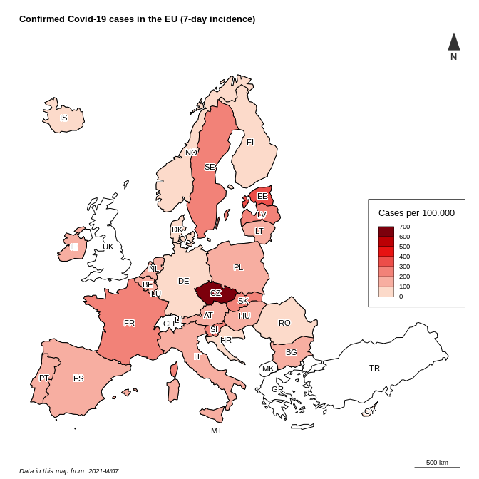

```r
layoutLayer(title = "Confirmed Covid-19 cases in the EU (7-day incidence)",
            frame = F,
            col = "white",
            coltitle = "black",
            author = paste("Data in this map from:", last_update),
            north = T,
            scale = 500)
labelLayer(spdf = nuts0.spdf, txt = "id", halo = T, show.lines = T)
```

The previous map, however, only shows the current situation without any information regarding the development of the epidemic over time. For this reason, the next diagram illustrates the data of confirmed Covid-19 cases over time since the beginning of the pandemic. The underlying data is again weekly data from the ECDC. This means that each data point represents the number of confirmed infections with Covid-19 in one week. For a better comparison of the different countries, the number of cases was normalised on 100.000 persons.

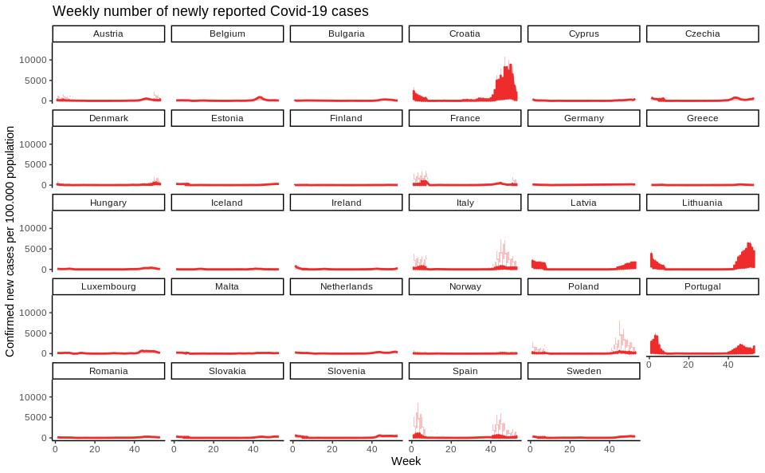

```r
# New cases
covid19_testing %>%
  mutate(new_cases_100k = 10^5*new_cases/population) %>%
  ggplot(aes(x = week, y = new_cases_100k)) +
    geom_line(color = casecol, lwd = 1) +
    geom_area(fill = casecol, alpha = 0.3) +
    facet_wrap(~country) +
    theme_classic() +
    labs(title = "Weekly number of newly reported Covid-19 cases",
         x = "Week",
         y = "Confirmed new cases per 100.000 population")
```

Since some people claim that the cases are only that high because we are testing more than in the beginning of the pandemic, the following two diagrams illustrate the testing rate, i.e. the number of performed tests per 100.000 people in the given period (in this case one week) as well as the positivity rate. The latter one is the percentage of positive tests from all performed tests for the given period.

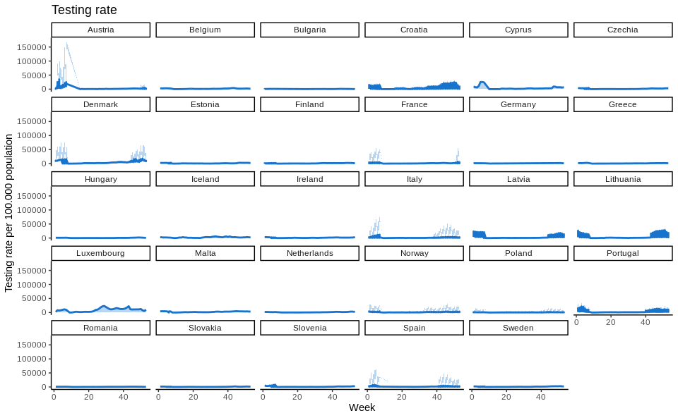

```r
# Testing rate
covid19_testing %>%
  ggplot(aes(x = week, y = testing_rate)) +
    geom_line(color = testcol, lwd = 1) +
    geom_area(fill = testcol, alpha = 0.3) +
    facet_wrap(~country) +
    theme_classic() +
    labs(title = "Testing rate",
         x = "Week",
         y = "Testing rate per 100.000 population")
```

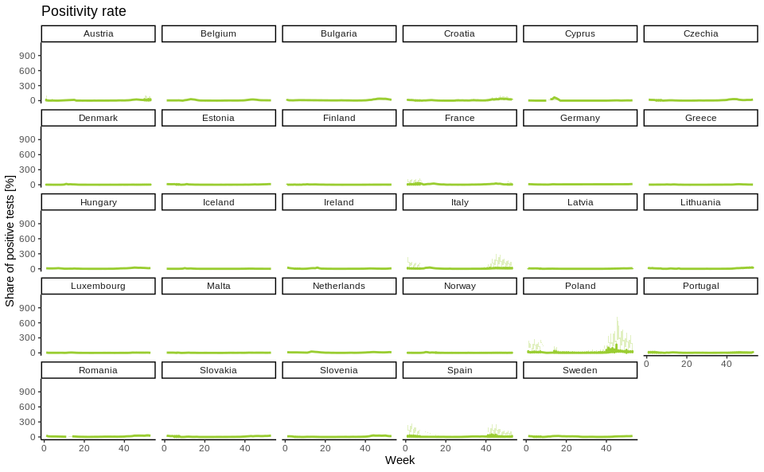

```r
# Positivity rate
covid19_testing %>%
  ggplot(aes(x = week, y = positivity_rate)) +
    geom_line(color = poscol, lwd = 1) +
    geom_area(fill = poscol, alpha = 0.3) +
    facet_wrap(~country) +
    theme_classic() +
    labs(title = "Positivity rate",
         x = "Week",
         y = "Share of positive tests [%]")
```

## USA

The data is taken directly from the [GitHub repository of the Johns Hopkins University](https://github.com/CSSEGISandData/COVID-19/blob/master/csse_covid_19_data/csse_covid_19_time_series/time_series_covid19_confirmed_US.csv). The following table provides an overview of the data structure using the first six rows of the data set:

```r
# Daten einlesen
url <- "https://github.com/CSSEGISandData/COVID-19/raw/master/csse_covid_19_data/csse_covid_19_time_series/time_series_covid19_confirmed_US.csv"

covid19_usa <- read_csv(url)

head(covid19_usa)
```

| UID | iso2 | iso3 | code3 | FIPS | Admin2 | Province_State | Country_Region | Lat | Long_ | Combined_Key | 1/22/20 | 1/23/20 | 1/24/20 | 1/25/20 | 1/26/20 | 1/27/20 | 1/28/20 | 1/29/20 | 1/30/20 | 1/31/20 | 2/1/20 | 2/2/20 | 2/3/20 | 2/4/20 | 2/5/20 | 2/6/20 | 2/7/20 | 2/8/20 | 2/9/20 | … |
| --- | --- | --- | --- | --- | --- | --- | --- | --- | --- | --- | --- | --- | --- | --- | --- | --- | --- | --- | --- | --- | --- | --- | --- | --- | --- | --- | --- | --- | --- | --- |
| 84001001 | US | USA | 840 | 1001 | Autauga | Alabama | US | 32.53953 | -86.64408 | Autauga, Alabama, US | 0 | 0 | 0 | 0 | 0 | 0 | 0 | 0 | 0 | 0 | 0 | 0 | 0 | 0 | 0 | 0 | 0 | 0 | 0 | … |
| 84001003 | US | USA | 840 | 1003 | Baldwin | Alabama | US | 30.72775 | -87.72207 | Baldwin, Alabama, US | 0 | 0 | 0 | 0 | 0 | 0 | 0 | 0 | 0 | 0 | 0 | 0 | 0 | 0 | 0 | 0 | 0 | 0 | 0 | … |
| 84001005 | US | USA | 840 | 1005 | Barbour | Alabama | US | 31.86826 | -85.38713 | Barbour, Alabama, US | 0 | 0 | 0 | 0 | 0 | 0 | 0 | 0 | 0 | 0 | 0 | 0 | 0 | 0 | 0 | 0 | 0 | 0 | 0 | … |
| 84001007 | US | USA | 840 | 1007 | Bibb | Alabama | US | 32.99642 | -87.12511 | Bibb, Alabama, US | 0 | 0 | 0 | 0 | 0 | 0 | 0 | 0 | 0 | 0 | 0 | 0 | 0 | 0 | 0 | 0 | 0 | 0 | 0 | … |
| 84001009 | US | USA | 840 | 1009 | Blount | Alabama | US | 33.98211 | -86.56791 | Blount, Alabama, US | 0 | 0 | 0 | 0 | 0 | 0 | 0 | 0 | 0 | 0 | 0 | 0 | 0 | 0 | 0 | 0 | 0 | 0 | 0 | … |
| 84001011 | US | USA | 840 | 1011 | Bullock | Alabama | US | 32.10031 | -85.71266 | Bullock, Alabama, US | 0 | 0 | 0 | 0 | 0 | 0 | 0 | 0 | 0 | 0 | 0 | 0 | 0 | 0 | 0 | 0 | 0 | 0 | 0 | … |

```r
covid19_usa_tidy <- covid19_usa %>%
  select(-c(UID, iso2, iso3, code3, Admin2, Country_Region, Lat, Long_)) %>%
  gather(-c(FIPS, Province_State, Combined_Key), key = "Date", value = "confirmed_cases") %>%
  mutate(Date = as.Date(Date, format = "%m/%d/%y"),
         fips = FIPS) %>% # schreibweise wichtig für usmap-Paket
  select(Date, Combined_Key, Province_State, fips, confirmed_cases)

covid19_prepared <- covid19_usa_tidy %>%
  group_by(Combined_Key) %>% # fips hat NA's. Stattdessen Combined_Key verwenden!
  mutate(previous_day = lag(confirmed_cases, n = 1L),
         new_cases = confirmed_cases-previous_day) %>%
  ungroup()

# Prepare the countypop data frame
countypop2015 <- usmap::countypop %>%
  mutate(fips = as.numeric(fips))

# Join the two data frames, exclude redundant variables and calculate cases per 100.000 people
covid19_normalised <- covid19_prepared %>%
  left_join(countypop2015, by = "fips") %>%
  select(-abbr, -county) %>%
  mutate(new_cases_100k = 10^5*new_cases/pop_2015)
```

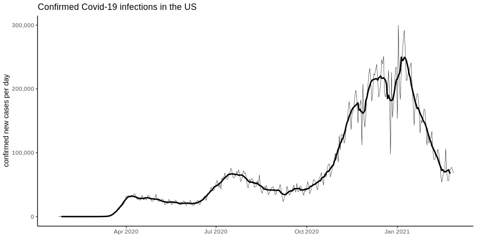

```r
# Total cases for the US
covid19_prepared %>%
  group_by(Date) %>%
  summarise(new_cases_total = sum(new_cases)) %>%
  mutate(rollmean_cases = rollmean(new_cases_total, 7, fill = NA)) %>%
  ggplot(aes(x = Date, y = new_cases_total)) +
    geom_line(lwd = 0.2) +
    geom_line(aes(y = rollmean_cases), lwd = 1) +
    scale_y_continuous(labels = scales::comma) +
    theme_classic() +
    labs(title = "Confirmed Covid-19 infections in the US",
         x = NULL,
         y = "confirmed new cases per day")
```

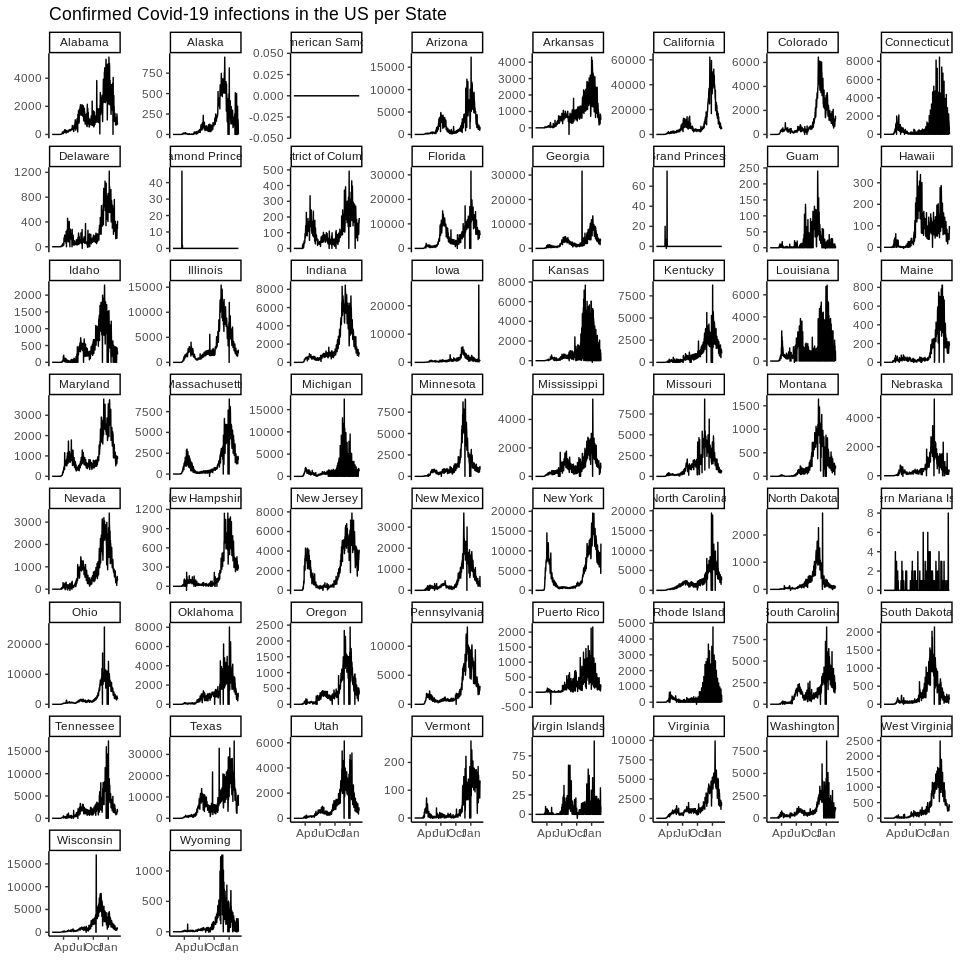

```r
# Cases per US-State
covid19_normalised %>%
  group_by(Date, Province_State) %>%
  summarise(state_sum = sum(new_cases, na.rm = T)) %>%
  ggplot(aes(x = Date, y = state_sum)) +
    geom_line() +
    facet_wrap(~Province_State, scales = "free_y") +
    scale_x_date(date_labels = "%b") +
    theme_classic() +
    labs(title = "Confirmed Covid-19 infections in the US per State",
         x = NULL,
         y = NULL)
```